# Sentiment Analysis over Moroccan politcal content based on Hespress comments

### Author : Ayoub RMIDI

## tags : Machine Learning - Naive Bayes - Sentiment analysis - NLP

#### This is an implementation of the Naive bayes _ machine learning algorithm integrated in a markdown document, doing the sentiment analysis job, based on a dataset of 2141 comment annotated as "neg" for Negative and "pos" for postive ones.

- **First of all we load our data set, and get it to data frame so that we can manipulate it easily**

```r
# loading the training tweets
df <- read.csv(file = "data/data_set.csv", stringsAsFactors = FALSE)
# get a summary of our data frame
glimpse(df)
```

[output not shown]

- **now lets have a better visualisation for our training data, so that we can get things much clear**

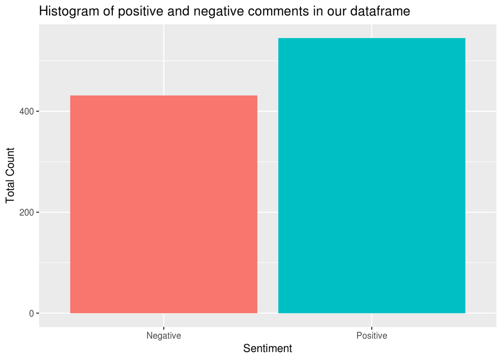

```r
positive <- length(which(df$class == "pos"))
negative <- length(which(df$class == "neg"))
Sentiment <- c("Negative","Positive")
Count <- c(negative, positive)
output <- data.frame(Sentiment,Count)
ggplot(data = output, aes(x = Sentiment, y = Count)) +
  geom_bar(aes(fill = Sentiment), stat = "identity") +
  theme(legend.position = "none") +
  xlab("Sentiment") + ylab("Total Count") + ggtitle("Histogram of positive and negative comments in our dataframe")
```

- **Randomize the dataset**

```r
set.seed(1)
df <- df[sample(nrow(df)), ]
df <- df[sample(nrow(df)), ]
glimpse(df)
```

[output not shown]

```r
# Convert the 'class' variable from character to factor.
df$class <- as.factor(df$class)
```

## Bag of Words Tokenisation

**In this implementation, we represent each word in a document as a token (or feature) and each document as a vector of features. In addition, for simplicity, we disregard word order and focus only on the number of occurrences of each word i.e., we represent each document as a multi-set ‘bag’ of words.**  
**We first prepare a corpus of all the documents in the dataframe.**

```r
corpus <- Corpus(VectorSource(df$text))
# Inspect the corpus
corpus
```

```
## <<SimpleCorpus>>
## Metadata:  corpus specific: 1, document level (indexed): 0
## Content:  documents: 2141
```

```r
inspect(corpus[4:7])
```

```
## <<SimpleCorpus>>
## Metadata:  corpus specific: 1, document level (indexed): 0
## Content:  documents: 4
##
## [1] C'est le Moment ou jamais . Si cet homme prend son courage à 2 mains pour dénoncer Elmakhzen qui dépouille les richesses du pays depuis l'indépendance il sera le martyr du peuple et la majorité des marocains pencheront pour son parti
## [2] mais il a fait allusion au blocage de la constitution de son gouvernement
## [3] profitent de cette situation. Ce sont de grands marchands des malheurs des peuples .\npos,On sait bien qu'il y'a 1 million de juifs marocains en israël qui conservent leur langue maternelle le darija on l'enseignant dans leurs écoles à leurs enfants qui naissent en israël pour saccrocher au m…
## [4] je vais pas commenter ce sujet puisque le maroc est dans son sahara et le sahara est dans son maroc,vive le roi,vive le peuple,louange a dieu.c est juste une petite histoure,pendant les premiers jours du ramadan lkarim,j etais dans une epicerie du quartier,j allais acheter du yoghourt,du lait…
```

## Data Cleanup

**Next, we clean up the corpus by eliminating numbers, punctuation, white space, and by converting to lower case. In addition, we discard common stop words such as “his”, “our”, “hadn’t”, couldn’t“, etc. We use the tm_map() function from the ‘tm’ package to this end.**

```r
 #Use dplyr's  %>% (pipe) utility to do this neatly.
corpus.clean <- corpus %>%
  tm_map(content_transformer(tolower)) %>%
  tm_map(removePunctuation) %>%
  tm_map(removeNumbers) %>%
  tm_map(removeWords, stopwords(kind="fr")) %>%
  tm_map(stripWhitespace)
```

## Matrix representation of Bag of Words : The Document Term Matrix

**We represent the bag of words tokens with a document term matrix (DTM). The rows of the DTM correspond to documents in the collection, columns correspond to terms, and its elements are the term frequencies. We use a built-in function from the ‘tm’ package to create the DTM.**

```r
dtm <- DocumentTermMatrix(corpus.clean)
# Inspect the dtm
inspect(dtm[50:60, 15:23])
```

[output not shown]

- **Taking a closer look, the histogram below is showing the frequency of occurences of unigrams.**

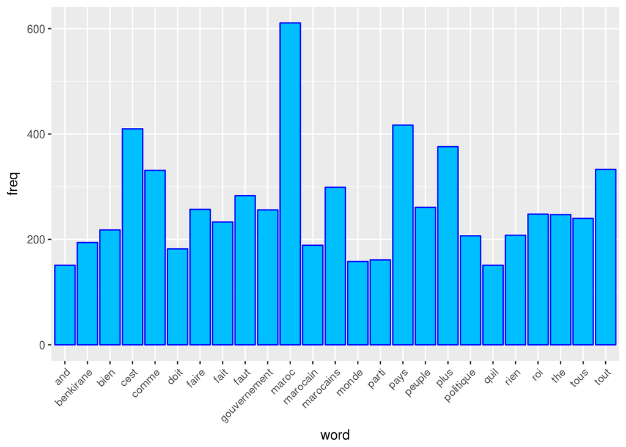

```r
# Frequency
freq <- sort(colSums(as.matrix(dtm)), decreasing=TRUE)
wf <- data.frame(word=names(freq), freq=freq)
# Plot Histogram
subset(wf, freq>150)    %>%
    ggplot(aes(word, freq)) +
    geom_bar(stat="identity", fill="deepskyblue", colour="blue") +
    theme(axis.text.x=element_text(angle=45, hjust=1))
```

## Partitioning the Data

**Next, we create 80:20 partitions of the dataframe, corpus and document term matrix for training and testing purposes.**

```r
df.train <- df[1:1713,]
df.test <- df[1714:2141,]

dtm.train <- dtm[1:1713,]
dtm.test <- dtm[1714:2141,]

corpus.clean.train <- corpus.clean[1:1713]
corpus.clean.test <- corpus.clean[1714:2141]
```

## Feature Selection

```r
dim(dtm.train)
```

```
## [1]  1713 13834
```

**The DTM contains 13834 features but not all of them will be useful for classification. We reduce the number of features by ignoring words which appear in less than five comments To do this, we use ‘findFreqTerms’ function to indentify the frequent words, we then restrict the DTM to use only the frequent words using the ‘dictionary’ option.**

```r
fivefreq <- findFreqTerms(dtm.train, 5)
length((fivefreq))
```

```
## [1] 1530
```

```r
# Use only 5 most frequent words (fivefreq) to build the DTM
dtm.train.nb <- DocumentTermMatrix(corpus.clean.train, control=list(dictionary = fivefreq))
dim(dtm.train.nb)
```

```
## [1] 1713 1530
```

```r
dtm.test.nb <- DocumentTermMatrix(corpus.clean.test, control=list(dictionary = fivefreq))
dim(dtm.train.nb)
```

```
## [1] 1713 1530
```

## The Naive Bayes algorithm

**The Naive Bayes text classification algorithm is essentially an application of Bayes theorem (with a strong independence assumption) to documents and classes.**

## Boolean feature Multinomial Naive Bayes

**We use a variation of the multinomial Naive Bayes algorithm known as [binarized (boolean feature) Naive Bayes](https://web.stanford.edu/~jurafsky/slp3/slides/7_Sent.pdf) due to Dan Jurafsky. In this method, the term frequencies are replaced by Boolean presence/absence features. The logic behind this being that for sentiment classification, word occurrence matters more than word frequency.**

```r
# Function to convert the word frequencies to yes (presence) and no (absence) labels
convert_count <- function(x) {
  y <- ifelse(x > 0, 1,0)
  y <- factor(y, levels=c(0,1), labels=c("No", "Yes"))
  y
}
```

```r
# Apply the convert_count function to get final training and testing DTMs
trainNB <- apply(dtm.train.nb, 2, convert_count)
testNB <- apply(dtm.test.nb, 2, convert_count)
```

## Training the Naive Bayes Model

**To train the model we use the naiveBayes function from the ‘e1071’ package. Since Naive Bayes evaluates products of probabilities, we need some way of assigning non-zero probabilities to words which do not occur in the sample. We use Laplace 1 smoothing to this end.**

```r
# Train the classifier
system.time( classifier <- naiveBayes(trainNB, df.train$class, laplace = 1) )
```

```
##    user  system elapsed
##   0.484   0.000   0.481
```

**Testing the Predictions**

```r
# Use the NB classifier we built to make predictions on the test set.
system.time( pred <- predict(classifier, newdata=testNB) )
```

```
##    user  system elapsed
##   130.156   0.000   130.141
```

```r
# Create a truth table by tabulating the predicted class labels with the actual class labels
x <- table("Predictions"= pred,  "Actual" = df.test$class ); x
```

[output not shown]

## Confusion matrix

```r
# Prepare the confusion matrix
conf.mat <- confusionMatrix(pred, df.test$class)

conf.mat
```

[output not shown]